# Analisis Performa Penjualan di Setiap Cabang pada Setiap Bulan

#### Tujuan dari project ini adalah melakukan automasi untuk pembuatan grafik dari perhitungan yang dibutuhkan.

```python
import numpy as np
import pandas as pd
import matplotlib.pyplot as plt
```

```python
df_retail_data1=pd.read_csv('retail_data_from_1_until_3.csv')
df_retail_data2=pd.read_csv('retail_data_from_4_until_6.csv')
df_retail_data3=pd.read_csv('retail_data_from_7_until_9.csv')
df_retail_data4=pd.read_csv('retail_data_from_10_until_12.csv')
```

```python
df_retail_data1
```

|  | Unnamed: 0 | order_id | order_date | customer_id | city | province | product_id | brand | quantity | item_price | total_price |
| --- | --- | --- | --- | --- | --- | --- | --- | --- | --- | --- | --- |
| 0 | 0 | 1612339 | 2019-01-01 | 18055 | Jakarta Selatan | DKI Jakarta | P0648 | BRAND_C | 4 | 1934000 | 7736000 |
| 1 | 1 | 1612339 | 2019-01-01 | 18055 | Jakarta Selatan | DKI Jakarta | P3826 | BRAND_V | 8 | 604000 | 4832000 |
| 2 | 2 | 1612339 | 2019-01-01 | 18055 | Jakarta Selatan | DKI Jakarta | P1508 | BRAND_G | 12 | 747000 | 8964000 |
| 3 | 3 | 1612339 | 2019-01-01 | 18055 | Jakarta Selatan | DKI Jakarta | P0520 | BRAND_B | 12 | 450000 | 5400000 |
| 4 | 4 | 1612339 | 2019-01-01 | 18055 | Jakarta Selatan | DKI Jakarta | P1513 | BRAND_G | 3 | 1500000 | 4500000 |
| ... | ... | ... | ... | ... | ... | ... | ... | ... | ... | ... | ... |
| 94883 | 94883 | 1637107 | 2019-03-31 | 14247 | Jakarta Utara | DKI Jakarta | P4009 | BRAND_W | 7 | 1045000 | 7315000 |
| 94884 | 94884 | 1637107 | 2019-03-31 | 14247 | Jakarta Utara | DKI Jakarta | P0929 | BRAND_C | 2 | 590000 | 1180000 |
| 94885 | 94885 | 1637107 | 2019-03-31 | 14247 | Jakarta Utara | DKI Jakarta | P2833 | BRAND_P | 6 | 904000 | 5424000 |
| 94886 | 94886 | 1637107 | 2019-03-31 | 14247 | Jakarta Utara | DKI Jakarta | P2572 | BRAND_P | 1 | 3494000 | 3494000 |
| 94887 | 94887 | 1637110 | 2019-03-31 | 0 | unknown | unknown | P1106 | BRAND_D | 1 | 2795000 | 2795000 |

94888 rows × 11 columns

```python
df_retail_data1.shape
```

```
(94888, 11)
```

```python
df_retail_data1.head()
```

|  | Unnamed: 0 | order_id | order_date | customer_id | city | province | product_id | brand | quantity | item_price | total_price |
| --- | --- | --- | --- | --- | --- | --- | --- | --- | --- | --- | --- |
| 0 | 0 | 1612339 | 2019-01-01 | 18055 | Jakarta Selatan | DKI Jakarta | P0648 | BRAND_C | 4 | 1934000 | 7736000 |
| 1 | 1 | 1612339 | 2019-01-01 | 18055 | Jakarta Selatan | DKI Jakarta | P3826 | BRAND_V | 8 | 604000 | 4832000 |
| 2 | 2 | 1612339 | 2019-01-01 | 18055 | Jakarta Selatan | DKI Jakarta | P1508 | BRAND_G | 12 | 747000 | 8964000 |
| 3 | 3 | 1612339 | 2019-01-01 | 18055 | Jakarta Selatan | DKI Jakarta | P0520 | BRAND_B | 12 | 450000 | 5400000 |
| 4 | 4 | 1612339 | 2019-01-01 | 18055 | Jakarta Selatan | DKI Jakarta | P1513 | BRAND_G | 3 | 1500000 | 4500000 |

```python
df_retail_data2
```

|  | Unnamed: 0 | order_id | order_date | customer_id | city | province | product_id | brand | quantity | item_price | total_price |
| --- | --- | --- | --- | --- | --- | --- | --- | --- | --- | --- | --- |
| 0 | 0 | 1637113 | 2019-04-01 | 16638 | Bandung | Jawa Barat | P0065 | BRAND_A | 4 | 2987000 | 11948000 |
| 1 | 1 | 1637113 | 2019-04-01 | 16638 | Bandung | Jawa Barat | P1025 | BRAND_D | 2 | 20995000 | 41990000 |
| 2 | 2 | 1637113 | 2019-04-01 | 16638 | Bandung | Jawa Barat | P0932 | BRAND_C | 6 | 1045000 | 6270000 |
| 3 | 3 | 1637113 | 2019-04-01 | 16638 | Bandung | Jawa Barat | P0933 | BRAND_C | 6 | 1045000 | 6270000 |
| 4 | 4 | 1637113 | 2019-04-01 | 16638 | Bandung | Jawa Barat | P1972 | BRAND_L | 2 | 2375000 | 4750000 |
| ... | ... | ... | ... | ... | ... | ... | ... | ... | ... | ... | ... |
| 101228 | 101228 | 1666738 | 2019-06-30 | 13983 | Surakarta | Jawa Tengah | P4121 | BRAND_W | 25 | 159000 | 3975000 |
| 101229 | 101229 | 1666738 | 2019-06-30 | 13983 | Surakarta | Jawa Tengah | P0672 | BRAND_C | 12 | 159000 | 1908000 |
| 101230 | 101230 | 1666738 | 2019-06-30 | 13983 | Surakarta | Jawa Tengah | P4077 | BRAND_W | 8 | 2987000 | 23896000 |
| 101231 | 101231 | 1666738 | 2019-06-30 | 13983 | Surakarta | Jawa Tengah | P1704 | BRAND_H | 48 | 310000 | 14880000 |
| 101232 | 101232 | 1666741 | 2019-06-30 | 13983 | Surakarta | Jawa Tengah | P4112 | BRAND_W | 25 | 159000 | 3975000 |

101233 rows × 11 columns

```python
df_retail_data2.shape
```

```
(101233, 11)
```

```python
df_retail_data2.head()
```

|  | Unnamed: 0 | order_id | order_date | customer_id | city | province | product_id | brand | quantity | item_price | total_price |
| --- | --- | --- | --- | --- | --- | --- | --- | --- | --- | --- | --- |
| 0 | 0 | 1637113 | 2019-04-01 | 16638 | Bandung | Jawa Barat | P0065 | BRAND_A | 4 | 2987000 | 11948000 |
| 1 | 1 | 1637113 | 2019-04-01 | 16638 | Bandung | Jawa Barat | P1025 | BRAND_D | 2 | 20995000 | 41990000 |
| 2 | 2 | 1637113 | 2019-04-01 | 16638 | Bandung | Jawa Barat | P0932 | BRAND_C | 6 | 1045000 | 6270000 |
| 3 | 3 | 1637113 | 2019-04-01 | 16638 | Bandung | Jawa Barat | P0933 | BRAND_C | 6 | 1045000 | 6270000 |
| 4 | 4 | 1637113 | 2019-04-01 | 16638 | Bandung | Jawa Barat | P1972 | BRAND_L | 2 | 2375000 | 4750000 |

```python
df_retail_data3
```

|  | Unnamed: 0 | order_id | order_date | customer_id | city | province | product_id | brand | quantity | item_price | total_price |
| --- | --- | --- | --- | --- | --- | --- | --- | --- | --- | --- | --- |
| 0 | 0 | 1666744 | 2019-07-01 | 13865 | Jakarta Selatan | DKI Jakarta | P1995 | BRAND_L | 2 | 2095000 | 4190000 |
| 1 | 1 | 1666744 | 2019-07-01 | 13865 | Jakarta Selatan | DKI Jakarta | P4194 | BRAND_Z | 3 | 2200000 | 6600000 |
| 2 | 2 | 1666744 | 2019-07-01 | 13865 | Jakarta Selatan | DKI Jakarta | P0255 | BRAND_A | 8 | 604000 | 4832000 |
| 3 | 3 | 1666744 | 2019-07-01 | 13865 | Jakarta Selatan | DKI Jakarta | P2366 | BRAND_O | 2 | 1745000 | 3490000 |
| 4 | 4 | 1666744 | 2019-07-01 | 13865 | Jakarta Selatan | DKI Jakarta | P3029 | BRAND_R | 10 | 590000 | 5900000 |
| ... | ... | ... | ... | ... | ... | ... | ... | ... | ... | ... | ... |
| 110605 | 110605 | 1696996 | 2019-09-30 | 15856 | Jakarta Utara | DKI Jakarta | P0714 | BRAND_C | 3 | 534000 | 1602000 |
| 110606 | 110606 | 1696996 | 2019-09-30 | 15856 | Jakarta Utara | DKI Jakarta | P1666 | BRAND_G | 2 | 800000 | 1600000 |
| 110607 | 110607 | 1696996 | 2019-09-30 | 15856 | Jakarta Utara | DKI Jakarta | P0605 | BRAND_B | 2 | 800000 | 1600000 |
| 110608 | 110608 | 1696996 | 2019-09-30 | 15856 | Jakarta Utara | DKI Jakarta | P0139 | BRAND_A | 1 | 800000 | 800000 |
| 110609 | 110609 | 1696996 | 2019-09-30 | 15856 | Jakarta Utara | DKI Jakarta | P3704 | BRAND_T | 2 | 1745000 | 3490000 |

110610 rows × 11 columns

```python
df_retail_data3.shape
```

```
(110610, 11)
```

```python
df_retail_data3.head()
```

|  | Unnamed: 0 | order_id | order_date | customer_id | city | province | product_id | brand | quantity | item_price | total_price |
| --- | --- | --- | --- | --- | --- | --- | --- | --- | --- | --- | --- |
| 0 | 0 | 1666744 | 2019-07-01 | 13865 | Jakarta Selatan | DKI Jakarta | P1995 | BRAND_L | 2 | 2095000 | 4190000 |
| 1 | 1 | 1666744 | 2019-07-01 | 13865 | Jakarta Selatan | DKI Jakarta | P4194 | BRAND_Z | 3 | 2200000 | 6600000 |
| 2 | 2 | 1666744 | 2019-07-01 | 13865 | Jakarta Selatan | DKI Jakarta | P0255 | BRAND_A | 8 | 604000 | 4832000 |
| 3 | 3 | 1666744 | 2019-07-01 | 13865 | Jakarta Selatan | DKI Jakarta | P2366 | BRAND_O | 2 | 1745000 | 3490000 |
| 4 | 4 | 1666744 | 2019-07-01 | 13865 | Jakarta Selatan | DKI Jakarta | P3029 | BRAND_R | 10 | 590000 | 5900000 |

```python
df_retail_data4
```

|  | Unnamed: 0 | order_id | order_date | customer_id | city | province | product_id | brand | quantity | item_price | total_price |
| --- | --- | --- | --- | --- | --- | --- | --- | --- | --- | --- | --- |
| 0 | 0 | 1697002 | 2019-10-01 | 17449 | Semarang | Jawa Tengah | P0652 | BRAND_C | 12 | 590000 | 7080000 |
| 1 | 1 | 1697002 | 2019-10-01 | 17449 | Semarang | Jawa Tengah | P2157 | BRAND_M | 8 | 1164000 | 9312000 |
| 2 | 2 | 1697002 | 2019-10-01 | 17449 | Semarang | Jawa Tengah | P3665 | BRAND_S | 2 | 2375000 | 4750000 |
| 3 | 3 | 1697002 | 2019-10-01 | 17449 | Semarang | Jawa Tengah | P1699 | BRAND_H | 12 | 450000 | 5400000 |
| 4 | 4 | 1697002 | 2019-10-01 | 17449 | Semarang | Jawa Tengah | P1200 | BRAND_E | 16 | 149000 | 2384000 |
| ... | ... | ... | ... | ... | ... | ... | ... | ... | ... | ... | ... |
| 201821 | 201821 | 1742998 | 2019-12-31 | 17883 | Jakarta Selatan | DKI Jakarta | P2218 | BRAND_M | 1 | 2987000 | 2987000 |
| 201822 | 201822 | 1742998 | 2019-12-31 | 17883 | Jakarta Selatan | DKI Jakarta | P0714 | BRAND_C | 2 | 149000 | 298000 |
| 201823 | 201823 | 1742998 | 2019-12-31 | 17883 | Jakarta Selatan | DKI Jakarta | P1838 | BRAND_I | 1 | 2987000 | 2987000 |
| 201824 | 201824 | 1742998 | 2019-12-31 | 17883 | Jakarta Selatan | DKI Jakarta | P3256 | BRAND_S | 5 | 695000 | 3475000 |
| 201825 | 201825 | 1742998 | 2019-12-31 | 17883 | Jakarta Selatan | DKI Jakarta | P1880 | BRAND_J | 6 | 219000 | 1314000 |

201826 rows × 11 columns

```python
df_retail_data4.shape
```

```
(201826, 11)
```

```python
df_retail_data4.head()
```

|  | Unnamed: 0 | order_id | order_date | customer_id | city | province | product_id | brand | quantity | item_price | total_price |
| --- | --- | --- | --- | --- | --- | --- | --- | --- | --- | --- | --- |
| 0 | 0 | 1697002 | 2019-10-01 | 17449 | Semarang | Jawa Tengah | P0652 | BRAND_C | 12 | 590000 | 7080000 |
| 1 | 1 | 1697002 | 2019-10-01 | 17449 | Semarang | Jawa Tengah | P2157 | BRAND_M | 8 | 1164000 | 9312000 |
| 2 | 2 | 1697002 | 2019-10-01 | 17449 | Semarang | Jawa Tengah | P3665 | BRAND_S | 2 | 2375000 | 4750000 |
| 3 | 3 | 1697002 | 2019-10-01 | 17449 | Semarang | Jawa Tengah | P1699 | BRAND_H | 12 | 450000 | 5400000 |
| 4 | 4 | 1697002 | 2019-10-01 | 17449 | Semarang | Jawa Tengah | P1200 | BRAND_E | 16 | 149000 | 2384000 |

#### Mengecek nama kolom pada setiap dataset

```python
print('Nama-nama kolom retail pada data ke-1:',df_retail_data1.columns)
print('Nama-nama kolom retail pada data ke-2:',df_retail_data2.columns)
print('Nama-nama kolom retail pada data ke-3:',df_retail_data3.columns)
print('Nama-nama kolom retail pada data ke-4:',df_retail_data4.columns)
```

```
Nama-nama kolom retail pada data ke-1: Index(['Unnamed: 0', 'order_id', 'order_date', 'customer_id', 'city',
       'province', 'product_id', 'brand', 'quantity', 'item_price',
       'total_price'],
      dtype='object')
Nama-nama kolom retail pada data ke-2: Index(['Unnamed: 0', 'order_id', 'order_date', 'customer_id', 'city',
       'province', 'product_id', 'brand', 'quantity', 'item_price',
       'total_price'],
      dtype='object')
Nama-nama kolom retail pada data ke-3: Index(['Unnamed: 0', 'order_id', 'order_date', 'customer_id', 'city',
       'province', 'product_id', 'brand', 'quantity', 'item_price',
       'total_price'],
      dtype='object')
Nama-nama kolom retail pada data ke-4: Index(['Unnamed: 0', 'order_id', 'order_date', 'customer_id', 'city',
       'province', 'product_id', 'brand', 'quantity', 'item_price',
       'total_price'],
      dtype='object')
```

#### Dari pengecekan nama kolom untuk setiap dataset, diketahui bahwa semua dataset mempunyai list kolom yang sama, sehingga informasi dari kolom-kolom tersebut dapat digabungkan.

```python
df_tabel_retail=pd.concat([df_retail_data1, df_retail_data2, df_retail_data3, df_retail_data4])
print('Jumlah baris pada tabel retail:', df_tabel_retail.shape[0])
```

```
Jumlah baris pada tabel retail: 508557
```

#### Mengecek ada tidaknya data NULL pada df_tabel_retail.

```python
df_tabel_retail.describe()
```

|  | Unnamed: 0 | customer_id | quantity | item_price | total_price |
| --- | --- | --- | --- | --- | --- |
| count | 508557.000000 | 508557.000000 | 508557.000000 | 5.085570e+05 | 5.085570e+05 |
| mean | 71004.479982 | 11509.957582 | 10.571326 | 1.357347e+06 | 7.043305e+06 |
| std | 49737.328863 | 6758.489806 | 112.805119 | 1.481544e+07 | 5.135112e+07 |
| min | 0.000000 | 0.000000 | 1.000000 | -3.871709e+09 | -3.871709e+09 |
| 25% | 31784.000000 | 12370.000000 | 1.000000 | 4.500000e+05 | 1.356000e+06 |
| 50% | 63569.000000 | 14388.000000 | 4.000000 | 7.400000e+05 | 3.498000e+06 |
| 75% | 95509.000000 | 16261.000000 | 11.000000 | 1.458000e+06 | 6.270000e+06 |
| max | 201825.000000 | 18287.000000 | 74215.000000 | 4.739478e+09 | 2.790484e+10 |

### Transformasi data

#### Pada langkah ini dilakukan tahapan untuk memastikan data yang memiliki item_price < 0 atau total_price < 0.

```python
data_cek=df_tabel_retail.loc[(df_tabel_retail['item_price'] < 0) | (df_tabel_retail['total_price'] < 0)]
```

```python
data_cek
```

|  | Unnamed: 0 | order_id | order_date | customer_id | city | province | product_id | brand | quantity | item_price | total_price |
| --- | --- | --- | --- | --- | --- | --- | --- | --- | --- | --- | --- |
| 83664 | 83664 | undefined | 2019-09-06 | 0 | unknown | unknown | P0153 | BRAND_A | 1 | -3871709000 | -3871709000 |
| 83665 | 83665 | undefined | 2019-09-06 | 0 | unknown | unknown | P0153 | BRAND_A | 1 | -3871709000 | -3871709000 |

#### Pada tabel diatas diketahui bahwa terdapat 2 data yang miliki item_price dan total_price yang tidak masuk akal, karena bernilai minus. Oleh karena itu, 2 data ini harus dihapus.

```python
if data_cek.shape[0] != 0:
    df_tabel_retail=df_tabel_retail.loc[(df_tabel_retail['item_price'] > 0) & (df_tabel_retail['total_price'] > 0)]
```

```python
data_cek=df_tabel_retail.loc[df_tabel_retail['order_id'] == 'undefined']
```

```python
data_cek
```

|  | Unnamed: 0 | order_id | order_date | customer_id | city | province | product_id | brand | quantity | item_price | total_price |
| --- | --- | --- | --- | --- | --- | --- | --- | --- | --- | --- | --- |
| 83663 | 83663 | undefined | 2019-09-06 | 0 | unknown | unknown | P0153 | BRAND_A | 1 | 3871733000 | 3871733000 |

#### Pada tabel diatas diketahui bahwa terdapat 1 data yang miliki order_id bernilai undefined. Oleh karena itu, 1 data ini harus dihapus.

```python
if data_cek.shape[0] != 0:
    df_tabel_retail=df_tabel_retail.loc[df_tabel_retail['order_id'] != 'undefined']
```

#### Transformasi kolom order_id menjadi int64 dan kolom order_date menjadi datetime (Pandas).

```python
df_tabel_retail['order_id']=df_tabel_retail['order_id'].astype('int64')
df_tabel_retail['order_id'].dtypes
```

```
dtype('int64')
```

```python
df_tabel_retail['order_date']=pd.to_datetime(df_tabel_retail['order_date'])
df_tabel_retail['order_date'].dtypes
```

```
dtype('<M8[ns]')
```

```python
df_tabel_retail.describe()
```

|  | Unnamed: 0 | order_id | customer_id | quantity | item_price | total_price |
| --- | --- | --- | --- | --- | --- | --- |
| count | 508554.000000 | 5.085540e+05 | 508554.000000 | 508554.000000 | 5.085540e+05 | 5.085540e+05 |
| mean | 71004.405302 | 1.680676e+06 | 11510.025480 | 10.571383 | 1.364968e+06 | 7.050960e+06 |
| std | 49737.466061 | 3.865433e+04 | 6758.451924 | 112.805449 | 1.144767e+07 | 5.048185e+07 |
| min | 0.000000 | 1.612339e+06 | 0.000000 | 1.000000 | 1.200000e+04 | 1.200000e+04 |
| 25% | 31784.000000 | 1.646143e+06 | 12370.000000 | 1.000000 | 4.500000e+05 | 1.356000e+06 |
| 50% | 63569.000000 | 1.682617e+06 | 14388.000000 | 4.000000 | 7.400000e+05 | 3.498000e+06 |
| 75% | 95509.750000 | 1.714960e+06 | 16261.000000 | 11.000000 | 1.458000e+06 | 6.270000e+06 |
| max | 201825.000000 | 1.742998e+06 | 18287.000000 | 74215.000000 | 4.739478e+09 | 2.790484e+10 |

#### Melakukan filter terhadap 5 besar provinsi yang akan dianalisis (DKI Jakarta, Jawa Barat, Jawa, Timur, Jawa Tengah, dan Yogyakarta).

```python
provinsi5=['DKI Jakarta', 'Jawa Barat', 'Jawa Timur', 'Jawa Tengah', 'Yogyakarta']
df_tabel_retail=df_tabel_retail.loc[df_tabel_retail['province'].isin(provinsi5)]
```

#### Memastikan filter terhadap 5 besar provinsi berhasil.

```python
print(df_tabel_retail.province.unique())
```

```
['DKI Jakarta' 'Jawa Barat' 'Jawa Timur' 'Yogyakarta' 'Jawa Tengah']
```

#### Mengelompokkan data berdasarkan order_date dan province yang sudah difilter diatas dan menghitung order_unique_count, customer unique_count, product_unique_count, brand_unique_count, dan Gross Merchandise Volume (GMV) atau total_price untuk semua penjualan.

```python
provinsi_group=df_tabel_retail.groupby(['order_date','province']).agg({
    'order_id' : 'nunique',
    'customer_id' : 'nunique',
    'product_id' : 'nunique',
    'brand' : 'nunique',
    'total_price' : 'nunique',
    'total_price' : sum
})
```

#### Mengubah nama kolom menjadi 'order', 'customer', 'product', 'brand', dan 'GMV'.

```python
provinsi_group.columns=['order', 'customer', 'product', 'brand', 'GMV']
```

```python
provinsi_group
```

| order_date | province | order | customer | product | brand | GMV |
| --- | --- | --- | --- | --- | --- | --- |
| 2019-01-01 | DKI Jakarta | 34 | 33 | 328 | 22 | 4717083000 |
|  | Jawa Barat | 11 | 9 | 136 | 18 | 1557289000 |
|  | Jawa Tengah | 4 | 4 | 116 | 20 | 352052000 |
|  | Jawa Timur | 6 | 6 | 83 | 15 | 1106603000 |
|  | Yogyakarta | 7 | 4 | 88 | 16 | 9454007000 |
| ... | ... | ... | ... | ... | ... | ... |
| 2019-12-31 | DKI Jakarta | 55 | 53 | 854 | 24 | 7761539000 |
|  | Jawa Barat | 12 | 11 | 186 | 21 | 1148204000 |
|  | Jawa Tengah | 10 | 8 | 113 | 17 | 2017737000 |
|  | Jawa Timur | 11 | 10 | 279 | 23 | 3115149000 |
|  | Yogyakarta | 9 | 8 | 90 | 19 | 728770000 |

1455 rows × 5 columns

```python
provinsi_group.shape
```

```
(1455, 5)
```

```python
provinsi_group.head()
```

| order_date | province | order | customer | product | brand | GMV |
| --- | --- | --- | --- | --- | --- | --- |
| 2019-01-01 | DKI Jakarta | 34 | 33 | 328 | 22 | 4717083000 |
|  | Jawa Barat | 11 | 9 | 136 | 18 | 1557289000 |
|  | Jawa Tengah | 4 | 4 | 116 | 20 | 352052000 |
|  | Jawa Timur | 6 | 6 | 83 | 15 | 1106603000 |
|  | Yogyakarta | 7 | 4 | 88 | 16 | 9454007000 |

#### Melakukan unstack untuk mendapatkan order_date di bagian baris dan province di bagian column.

```python
unstack_provinsi_group=provinsi_group.unstack(level='province').fillna(0)
```

```python
unstack_provinsi_group
```

| province order_date | order DKI Jakarta | order Jawa Barat | order Jawa Tengah | order Jawa Timur | order Yogyakarta | customer DKI Jakarta | customer Jawa Barat | customer Jawa Tengah | customer Jawa Timur | customer Yogyakarta | ... | brand DKI Jakarta | brand Jawa Barat | brand Jawa Tengah | brand Jawa Timur | brand Yogyakarta | GMV DKI Jakarta | GMV Jawa Barat | GMV Jawa Tengah | GMV Jawa Timur | GMV Yogyakarta |
| --- | --- | --- | --- | --- | --- | --- | --- | --- | --- | --- | --- | --- | --- | --- | --- | --- | --- | --- | --- | --- | --- |
| 2019-01-01 | 34.0 | 11.0 | 4.0 | 6.0 | 7.0 | 33.0 | 9.0 | 4.0 | 6.0 | 4.0 | ... | 22.0 | 18.0 | 20.0 | 15.0 | 16.0 | 4.717083e+09 | 1.557289e+09 | 3.520520e+08 | 1.106603e+09 | 9.454007e+09 |
| 2019-01-02 | 58.0 | 17.0 | 8.0 | 6.0 | 12.0 | 50.0 | 14.0 | 7.0 | 6.0 | 12.0 | ... | 25.0 | 21.0 | 18.0 | 17.0 | 23.0 | 6.218886e+09 | 1.458207e+09 | 9.682730e+08 | 9.016760e+08 | 1.509057e+09 |
| 2019-01-03 | 43.0 | 13.0 | 8.0 | 8.0 | 10.0 | 40.0 | 13.0 | 7.0 | 6.0 | 9.0 | ... | 23.0 | 22.0 | 18.0 | 18.0 | 23.0 | 4.670172e+09 | 1.797040e+09 | 6.632580e+08 | 1.189519e+09 | 1.582902e+09 |
| 2019-01-04 | 39.0 | 9.0 | 11.0 | 2.0 | 3.0 | 25.0 | 7.0 | 9.0 | 2.0 | 3.0 | ... | 24.0 | 18.0 | 17.0 | 14.0 | 19.0 | 6.724529e+09 | 1.805267e+09 | 7.104560e+08 | 2.418780e+08 | 5.945680e+08 |
| 2019-01-06 | 22.0 | 9.0 | 3.0 | 4.0 | 2.0 | 22.0 | 9.0 | 3.0 | 3.0 | 2.0 | ... | 25.0 | 23.0 | 10.0 | 19.0 | 12.0 | 2.483318e+09 | 1.558771e+09 | 3.089750e+08 | 2.157180e+08 | 1.221680e+08 |
| ... | ... | ... | ... | ... | ... | ... | ... | ... | ... | ... | ... | ... | ... | ... | ... | ... | ... | ... | ... | ... | ... |
| 2019-12-26 | 57.0 | 22.0 | 7.0 | 16.0 | 4.0 | 54.0 | 21.0 | 7.0 | 14.0 | 4.0 | ... | 24.0 | 21.0 | 21.0 | 21.0 | 17.0 | 7.775259e+09 | 2.665867e+09 | 1.241638e+09 | 1.905929e+09 | 5.526000e+08 |
| 2019-12-27 | 51.0 | 17.0 | 15.0 | 10.0 | 9.0 | 40.0 | 16.0 | 14.0 | 7.0 | 7.0 | ... | 22.0 | 24.0 | 20.0 | 19.0 | 21.0 | 5.968947e+09 | 2.379433e+09 | 3.079970e+09 | 1.563477e+09 | 1.147019e+09 |
| 2019-12-29 | 35.0 | 11.0 | 4.0 | 1.0 | 4.0 | 33.0 | 9.0 | 4.0 | 1.0 | 4.0 | ... | 23.0 | 22.0 | 18.0 | 4.0 | 18.0 | 4.164912e+09 | 1.144196e+09 | 2.080520e+08 | 1.000370e+08 | 5.912590e+08 |
| 2019-12-30 | 64.0 | 13.0 | 12.0 | 8.0 | 5.0 | 57.0 | 13.0 | 11.0 | 7.0 | 5.0 | ... | 25.0 | 21.0 | 25.0 | 20.0 | 18.0 | 1.047914e+10 | 1.265811e+09 | 4.634513e+09 | 1.724699e+09 | 6.004540e+08 |
| 2019-12-31 | 55.0 | 12.0 | 10.0 | 11.0 | 9.0 | 53.0 | 11.0 | 8.0 | 10.0 | 8.0 | ... | 24.0 | 21.0 | 17.0 | 23.0 | 19.0 | 7.761539e+09 | 1.148204e+09 | 2.017737e+09 | 3.115149e+09 | 7.287700e+08 |

297 rows × 25 columns

```python
unstack_provinsi_group.shape
```

```
(297, 25)
```

```python
unstack_provinsi_group.head()
```

| province order_date | order DKI Jakarta | order Jawa Barat | order Jawa Tengah | order Jawa Timur | order Yogyakarta | customer DKI Jakarta | customer Jawa Barat | customer Jawa Tengah | customer Jawa Timur | customer Yogyakarta | ... | brand DKI Jakarta | brand Jawa Barat | brand Jawa Tengah | brand Jawa Timur | brand Yogyakarta | GMV DKI Jakarta | GMV Jawa Barat | GMV Jawa Tengah | GMV Jawa Timur | GMV Yogyakarta |
| --- | --- | --- | --- | --- | --- | --- | --- | --- | --- | --- | --- | --- | --- | --- | --- | --- | --- | --- | --- | --- | --- |
| 2019-01-01 | 34.0 | 11.0 | 4.0 | 6.0 | 7.0 | 33.0 | 9.0 | 4.0 | 6.0 | 4.0 | ... | 22.0 | 18.0 | 20.0 | 15.0 | 16.0 | 4.717083e+09 | 1.557289e+09 | 352052000.0 | 1.106603e+09 | 9.454007e+09 |
| 2019-01-02 | 58.0 | 17.0 | 8.0 | 6.0 | 12.0 | 50.0 | 14.0 | 7.0 | 6.0 | 12.0 | ... | 25.0 | 21.0 | 18.0 | 17.0 | 23.0 | 6.218886e+09 | 1.458207e+09 | 968273000.0 | 9.016760e+08 | 1.509057e+09 |
| 2019-01-03 | 43.0 | 13.0 | 8.0 | 8.0 | 10.0 | 40.0 | 13.0 | 7.0 | 6.0 | 9.0 | ... | 23.0 | 22.0 | 18.0 | 18.0 | 23.0 | 4.670172e+09 | 1.797040e+09 | 663258000.0 | 1.189519e+09 | 1.582902e+09 |
| 2019-01-04 | 39.0 | 9.0 | 11.0 | 2.0 | 3.0 | 25.0 | 7.0 | 9.0 | 2.0 | 3.0 | ... | 24.0 | 18.0 | 17.0 | 14.0 | 19.0 | 6.724529e+09 | 1.805267e+09 | 710456000.0 | 2.418780e+08 | 5.945680e+08 |
| 2019-01-06 | 22.0 | 9.0 | 3.0 | 4.0 | 2.0 | 22.0 | 9.0 | 3.0 | 3.0 | 2.0 | ... | 25.0 | 23.0 | 10.0 | 19.0 | 12.0 | 2.483318e+09 | 1.558771e+09 | 308975000.0 | 2.157180e+08 | 1.221680e+08 |

5 rows × 25 columns

#### Visualisasi berupa grafik untuk masing-masing parameter perhitungan melalui slicing dan resampling untuk mendapatkan perhitungan rata-rata bulanan untuk masing-masing parameter perhitungan.

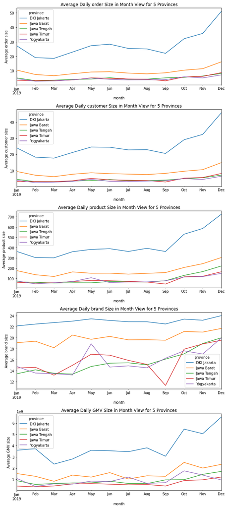

```python
#Membuat figure canvas dan axes untuk lima line plots.
figure,axes=plt.subplots(5, 1, figsize =(9,20))

#Slicing index
index=pd.IndexSlice['order', 'customer', 'product', 'brand', 'GMV']
for i, measurement in enumerate(provinsi_group.columns):
    #Slicing data untuk masing-masing measurement
    by_measurement=unstack_provinsi_group.loc[:, index[i]]
    #Melakukan resampling pada data untuk perhitungan rata-rata bulanan
    monthly_by_measurement_mean=by_measurement.resample('M').mean()
    #Plotting monthly_by_measurement_mean
    monthly_by_measurement_mean.plot(title='Average Daily ' + measurement + ' Size in Month View for 5 Provinces', ax=axes[i])
    axes[i].set_ylabel('Average ' + measurement + ' size')
    axes[i].set_xlabel('month')

plt.tight_layout()
plt.show()
```

Berdasarkan grafik diatas dapat disimpulkan bahwa sebagian esar performa dari cabang-cabang untuk lima provinsi tersebut mengalami kenaikan namun sempat terjadi penurun pada bulan September khususnya pada cabang di Provinsi Jawa Timur.